# Risk of Business Failure

Libraries

```r
# install.packages("sjmisc")
# devtools::install_github("ropensci/skimr")

library(skimr)
library(ggplot2)
library(hrbrthemes)
library(forcats)
library(plyr)
library(plugdensity)
```

Import & Setup AIDA dataset

```r
# clean all
rm(list=ls())

# working dir
wdir_fg = "/Users/francescogemignani/Google Drive/SMD/_Risk-of-business-failure/git"
wdir_ff = "C:/Users/falle/OneDrive - University of Pisa/Data Science/Statistical Methods for Data Science/smdproject2021"
wdir_sc = "/Users/samuele/University/2.SMD/Risk-of-Business-Failure"
setwd(wdir_fg)

# import aida dataset
load(file="../aida.RData")

# For each attribute name, replace all white space whit dot symbol
colnames(aida) <- gsub(" ",".",colnames(aida))
```

Summary

```r
skim(aida)
```

```
── Data Summary ────────────────────────
                           Values
Name                       aida
Number of rows             1894412
Number of columns          80
_______________________
Column type frequency:
  character                3
  factor                   6
  numeric                  71
________________________
Group variables            None

── Variable type: character ──────────────────────────────────────────────────────────────────────────────────────────────────────────────────────────────────────
  skim_variable   n_missing complete_rate   min   max empty n_unique whitespace
```

[output cut: 86 more lines]

Failed

```r
# Add 'Failed' feature to AIDA dataset. It describe if a company is failed or not regardless of the cause. In particular a company with Legal status no active has marked with Failed = Yes,,
# otherwise Failed = No when has labeled as Active.

# Missing values don't occour
aida[is.na(aida$Legal.status),]
```

| ATECO.2007code | Banks/turnover%Last.avail..yr | Banks/turnover%Year.-.1 | Banks/turnover%Year.-.2 | Cash.Flowth.EURLast.avail..yr | Cash.Flowth.EURYear.-.1 | Cash.Flowth.EURYear.-.2 | Company.name | Cost.of.debit.(%)%Last.avail..yr | Cost.of.debit.(%)%Year.-.1 | Cost.of.debit.(%)%Year.-.2 | Current.liabilities/Tot.ass.%Last.avail..yr | Current.liabilities/Tot.ass.%Year.-.1 | Current.liabilities/Tot.ass.%Year.-.2 | Current.ratioLast.avail..yr | Current.ratioYear.-.1 | Current.ratioYear.-.2 | Debt/EBITDA.ratio%Last.avail..yr | Debt/EBITDA.ratio%Year.-.1 | Debt/EBITDA.ratio%Year.-.2 | Debt/equity.ratio%Last.avail..yr | Debt/equity.ratio%Year.-.1 | Debt/equity.ratio%Year.-.2 | EBITDA/Vendite%Last.avail..yr | EBITDA/Vendite%Year.-.1 | EBITDA/Vendite%Year.-.2 | EBITDAth.EURLast.avail..yr | EBITDAth.EURYear.-.1 | EBITDAth.EURYear.-.2 | File | … |
| --- | --- | --- | --- | --- | --- | --- | --- | --- | --- | --- | --- | --- | --- | --- | --- | --- | --- | --- | --- | --- | --- | --- | --- | --- | --- | --- | --- | --- | --- | --- |

```r
# Table of Legal status
table(aida$Legal.status)*100/nrow(aida)
```

```
                      Active Active (default of payments)        Active (receivership)                   Bankruptcy                    Dissolved
                 62.57308336                   0.20264863                   0.02554882                   5.63182666                  11.96666829
      Dissolved (bankruptcy)         Dissolved (demerger)      Dissolved (liquidation)           Dissolved (merger)               In liquidation
                  0.35726125                   0.04629405                   7.47646235                   2.92444305                   8.79576354
```

```r
# Make the operator
'%!in%' <- function(x,y)!('%in%'(x,y))

# Add new empty column
aida$Failed <- NULL

# For each 'Legal status' which contains 'Active' substring fill in new column 'No' else 'Yes'
act_vector <- c('Active','Active (default of payments)','Active (receivership)')
aida[aida$Legal.status %in% act_vector,'Failed'] <- 'No'
aida[aida$Legal.status %!in% act_vector,'Failed'] <- 'Yes'

aida[is.na(aida$Failed), ]
```

| ATECO.2007code | Banks/turnover%Last.avail..yr | Banks/turnover%Year.-.1 | Banks/turnover%Year.-.2 | Cash.Flowth.EURLast.avail..yr | Cash.Flowth.EURYear.-.1 | Cash.Flowth.EURYear.-.2 | Company.name | Cost.of.debit.(%)%Last.avail..yr | Cost.of.debit.(%)%Year.-.1 | Cost.of.debit.(%)%Year.-.2 | Current.liabilities/Tot.ass.%Last.avail..yr | Current.liabilities/Tot.ass.%Year.-.1 | Current.liabilities/Tot.ass.%Year.-.2 | Current.ratioLast.avail..yr | Current.ratioYear.-.1 | Current.ratioYear.-.2 | Debt/EBITDA.ratio%Last.avail..yr | Debt/EBITDA.ratio%Year.-.1 | Debt/EBITDA.ratio%Year.-.2 | Debt/equity.ratio%Last.avail..yr | Debt/equity.ratio%Year.-.1 | Debt/equity.ratio%Year.-.2 | EBITDA/Vendite%Last.avail..yr | EBITDA/Vendite%Year.-.1 | EBITDA/Vendite%Year.-.2 | EBITDAth.EURLast.avail..yr | EBITDAth.EURYear.-.1 | EBITDAth.EURYear.-.2 | File | … |
| --- | --- | --- | --- | --- | --- | --- | --- | --- | --- | --- | --- | --- | --- | --- | --- | --- | --- | --- | --- | --- | --- | --- | --- | --- | --- | --- | --- | --- | --- | --- |

```r
# Failed info
table(aida$Failed)*100/nrow(aida)
```

```
      No      Yes
62.80128 37.19872
```

Legal Status by Failed

```r
table(aida$Failed)*100/nrow(aida)
```

```
      No      Yes
62.80128 37.19872
```

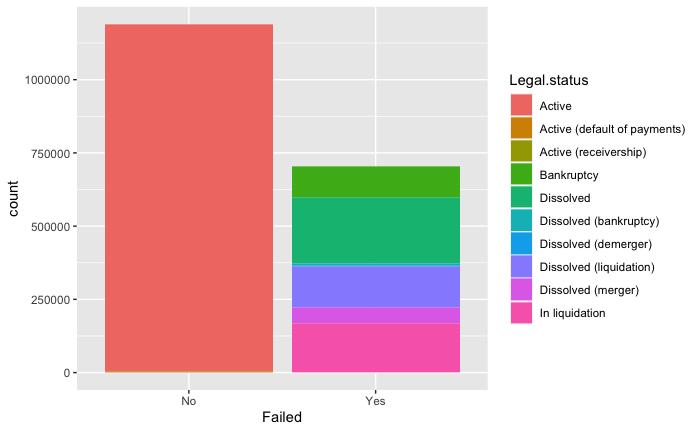

```r
ggplot(data=aida, aes(x=Failed, fill=Legal.status)) +
  geom_bar() +
  scale_fill_hue(c = 90)
```

Legal Form by Failed

```r
table(aida$Failed)*100/nrow(aida)
```

```
      No      Yes
62.80128 37.19872
```

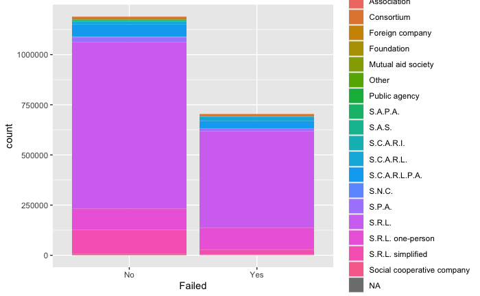

```r
ggplot(data=aida, aes(x=Failed, fill=Legal.form)) +
  geom_bar() +
  scale_fill_hue(c = 90)
```

ATECO Sectors

```r
# Add a column with the respective ISTAT sector of the company. In particular first two digits of ATECO 2007code identify the company sector which is an upper case character that began to [A-U] alphabetical range.

#Delete record with ADECO code null (18327)
aida <- aida[!is.na(aida$ATECO.2007code),]

# Add the attribute 'ATECO.Sector.Code' which contain the characters of the sector identified by the first two ATECO 2007 code digits.
aida$ATECO.Sector.Code <- NULL
aida$ATECO.Sector.Code <- substr(aida$ATECO.2007code, 0, 2)

# Make a dataframe called istat.sectors.map, which contains two features:
# 1. ATECO.Sector.Code: first two digits of 'ATECO 2007code'
# 2. ATECO.Sector.Name: the respective sector name of that ATECO.Sector.Code
# Istat sectors can be found in https://www.istat.it/it/archivio/17888

ATECO.Sector.Code <- c('01', '02', '03', '05', '06', '07', '08', '09', '10', '11', '12', '13', '14', '15', '16', '17', '18', '19', '20', '21', '22', '23', '24', '25', '26', '27', '28', '29', '30', '31', '32', '33', '35', '36', '37', '38', '39', '41', '42', '43', '45', '46', '47', '49', '50', '51', '52', '53', '55', '56', '58', '59', '60', '61', '62', '63', '64', '65', '66', '68', '69', '70', '71', '72', '73', '74', '75', '77', '78', '79', '80', '81', '82', '84', '85', '86', '87', '88', '90', '91', '92', '93', '94', '95', '96', '97', '98', '99', '00')

ATECO.Sector.Name <- c('A', 'A', 'A', 'B', 'B', 'B', 'B', 'B', 'C', 'C', 'C', 'C', 'C', 'C', 'C', 'C', 'C', 'C', 'C', 'C', 'C', 'C', 'C', 'C', 'C', 'C', 'C', 'C', 'C', 'C', 'C', 'C', 'D', 'E', 'E', 'E', 'E', 'F', 'F', 'F', 'G', 'G', 'G', 'H', 'H', 'H', 'H', 'H', 'I', 'I', 'J', 'J', 'J', 'J', 'J', 'J', 'K', 'K', 'K', 'L', 'M', 'M', 'M', 'M', 'M', 'M', 'M', 'N', 'N', 'N', 'N', 'N', 'N', 'O', 'P', 'Q', 'Q', 'Q', 'R', 'R', 'R', 'R', 'S', 'S', 'S', 'T', 'T','U', 'no.sector')

ATECO.Sector.Description <- c('AGRICOLTURA, SILVICOLTURA E PESCA', 'AGRICOLTURA, SILVICOLTURA E PESCA', 'AGRICOLTURA, SILVICOLTURA E PESCA','ESTRAZIONE DI MINERALI DA CAVE E MINIERE', 'ESTRAZIONE DI MINERALI DA CAVE E MINIERE', 'ESTRAZIONE DI MINERALI DA CAVE E MINIERE', 'ESTRAZIONE DI MINERALI DA CAVE E MINIERE', 'ESTRAZIONE DI MINERALI DA CAVE E MINIERE', 'ATTIVITÀ MANIFATTURIERE', 'ATTIVITÀ MANIFATTURIERE', 'ATTIVITÀ MANIFATTURIERE', 'ATTIVITÀ MANIFATTURIERE', 'ATTIVITÀ MANIFATTURIERE', 'ATTIVITÀ MANIFATTURIERE', 'ATTIVITÀ MANIFATTURIERE', 'ATTIVITÀ MANIFATTURIERE', 'ATTIVITÀ MANIFATTURIERE', 'ATTIVITÀ MANIFATTURIERE', 'ATTIVITÀ MANIFATTURIERE', 'ATTIVITÀ MANIFATTURIERE', 'ATTIVITÀ MANIFATTURIERE', 'ATTIVITÀ MANIFATTURIERE', 'ATTIVITÀ MANIFATTURIERE', 'ATTIVITÀ MANIFATTURIERE', 'ATTIVITÀ MANIFATTURIERE', 'ATTIVITÀ MANIFATTURIERE', 'ATTIVITÀ MANIFATTURIERE', 'ATTIVITÀ MANIFATTURIERE', 'ATTIVITÀ MANIFATTURIERE', 'ATTIVITÀ MANIFATTURIERE', 'ATTIVITÀ MANIFATTURIERE', 'ATTIVITÀ MANIFATTURIERE', 'FORNITURA DI ENERGIA ELETTRICA, GAS, VAPORE E ARIA CONDIZIONATA', 'FORNITURA DI ACQUA; RETI FOGNARIE, ATTIVITÀ DI GESTIONE DEI RIFIUTI E RISANAMENTO', 'FORNITURA DI ACQUA; RETI FOGNARIE, ATTIVITÀ DI GESTIONE DEI RIFIUTI E RISANAMENTO', 'FORNITURA DI ACQUA; RETI FOGNARIE, ATTIVITÀ DI GESTIONE DEI RIFIUTI E RISANAMENTO', 'FORNITURA DI ACQUA; RETI FOGNARIE, ATTIVITÀ DI GESTIONE DEI RIFIUTI E RISANAMENTO', 'COSTRUZIONI', 'COSTRUZIONI', 'COSTRUZIONI', 'COMMERCIO ALL INGROSSO E AL DETTAGLIO; RIPARAZIONE DI AUTOVEICOLI E MOTOCICLI', 'COMMERCIO ALL INGROSSO E AL DETTAGLIO; RIPARAZIONE DI AUTOVEICOLI E MOTOCICLI', 'COMMERCIO ALL INGROSSO E AL DETTAGLIO; RIPARAZIONE DI AUTOVEICOLI E MOTOCICLI', 'TRASPORTO E MAGAZZINAGGIO', 'TRASPORTO E MAGAZZINAGGIO', 'TRASPORTO E MAGAZZINAGGIO', 'TRASPORTO E MAGAZZINAGGIO', 'TRASPORTO E MAGAZZINAGGIO', 'ATTIVITÀ DEI SERVIZI DI ALLOGGIO E DI RISTORAZIONE', 'ATTIVITÀ DEI SERVIZI DI ALLOGGIO E DI RISTORAZIONE', 'SERVIZI DI INFORMAZIONE E COMUNICAZIONE', 'SERVIZI DI INFORMAZIONE E COMUNICAZIONE', 'SERVIZI DI INFORMAZIONE E COMUNICAZIONE', 'SERVIZI DI INFORMAZIONE E COMUNICAZIONE', 'SERVIZI DI INFORMAZIONE E COMUNICAZIONE', 'SERVIZI DI INFORMAZIONE E COMUNICAZIONE', 'ATTIVITÀ FINANZIARIE E ASSICURATIVE', 'ATTIVITÀ FINANZIARIE E ASSICURATIVE', 'ATTIVITÀ FINANZIARIE E ASSICURATIVE', 'ATTIVITÀ IMMOBILIARI', 'ATTIVITÀ PROFESSIONALI, SCIENTIFICHE E TECNICHE', 'ATTIVITÀ PROFESSIONALI, SCIENTIFICHE E TECNICHE', 'ATTIVITÀ PROFESSIONALI, SCIENTIFICHE E TECNICHE', 'ATTIVITÀ PROFESSIONALI, SCIENTIFICHE E TECNICHE', 'ATTIVITÀ PROFESSIONALI, SCIENTIFICHE E TECNICHE', 'ATTIVITÀ PROFESSIONALI, SCIENTIFICHE E TECNICHE', 'ATTIVITÀ PROFESSIONALI, SCIENTIFICHE E TECNICHE', 'NOLEGGIO, AGENZIE DI VIAGGIO, SERVIZI DI SUPPORTO ALLE IMPRESE', 'NOLEGGIO, AGENZIE DI VIAGGIO, SERVIZI DI SUPPORTO ALLE IMPRESE', 'NOLEGGIO, AGENZIE DI VIAGGIO, SERVIZI DI SUPPORTO ALLE IMPRESE', 'NOLEGGIO, AGENZIE DI VIAGGIO, SERVIZI DI SUPPORTO ALLE IMPRESE', 'NOLEGGIO, AGENZIE DI VIAGGIO, SERVIZI DI SUPPORTO ALLE IMPRESE', 'NOLEGGIO, AGENZIE DI VIAGGIO, SERVIZI DI SUPPORTO ALLE IMPRESE', 'AMMINISTRAZIONE PUBBLICA E DIFESA; ASSICURAZIONE SOCIALE OBBLIGATORIA', 'ISTRUZIONE', 'SANITÀ E ASSISTENZA SOCIALE', 'SANITÀ E ASSISTENZA SOCIALE', 'SANITÀ E ASSISTENZA SOCIALE', 'ATTIVITÀ ARTISTICHE, SPORTIVE, DI INTRATTENIMENTO E DIVERTIMENTO', 'ATTIVITÀ ARTISTICHE, SPORTIVE, DI INTRATTENIMENTO E DIVERTIMENTO', 'ATTIVITÀ ARTISTICHE, SPORTIVE, DI INTRATTENIMENTO E DIVERTIMENTO', 'ATTIVITÀ ARTISTICHE, SPORTIVE, DI INTRATTENIMENTO E DIVERTIMENTO', 'ALTRE ATTIVITÀ DI SERVIZI', 'ALTRE ATTIVITÀ DI SERVIZI', 'ALTRE ATTIVITÀ DI SERVIZI', 'ATTIVITÀ DI FAMIGLIE E CONVIVENZE COME DATORI DI LAVORO PER PERSONALE DOMESTICO', 'ATTIVITÀ DI FAMIGLIE E CONVIVENZE COME DATORI DI LAVORO PER PERSONALE DOMESTICO','ORGANIZZAZIONI ED ORGANISMI EXTRATERRITORIALI', 'no.sector')

istat.sectors.map <- data.frame(ATECO.Sector.Code=ATECO.Sector.Code, ATECO.Sector.Name=ATECO.Sector.Name, ATECO.Sector.Description=ATECO.Sector.Description)

# Merge istat.sectors.map with AIDA dataframe, by ATECO.Sector.Code key
aida <- merge(aida,istat.sectors.map,by="ATECO.Sector.Code")

# Delete ATECO.Sector.Code feature, because we already have the secor name.
aida$ATECO.Sector.Code <- NULL

# Cast ATECO.Sector.Name as Factor
aida$ATECO.Sector.Name <- as.factor(aida$ATECO.Sector.Name)

# Description of ISTAT sectors
# https://www.istat.it/it/archivio/17888
# http://www.fr.camcom.gov.it/sites/default/files/cciaa/RinnovoConsiglio/ateco-2007-struttura.pdf
```

Legal Status Bar Plot

```r
#Remove Missing Values
aida <- aida[!is.na(aida$Legal.form),]

table(aida$Legal.status)*100/nrow(aida)
```

```
                      Active Active (default of payments)        Active (receivership)                   Bankruptcy                    Dissolved
                 62.98119804                   0.20466927                   0.02569695                   5.67326808                  11.65980437
      Dissolved (bankruptcy)         Dissolved (demerger)      Dissolved (liquidation)           Dissolved (merger)               In liquidation
                  0.35981061                   0.04664903                   7.33008159                   2.90796707                   8.81085499
```

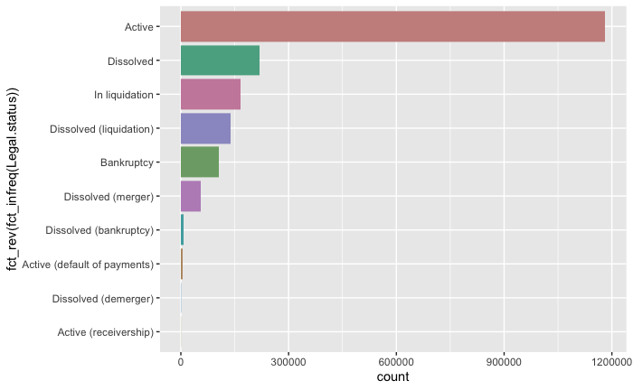

```r
ggplot(data=aida, aes(x=fct_rev(fct_infreq(Legal.status)), fill=Legal.status)) +
  geom_bar() +
  scale_fill_hue(c = 40) +
  theme(legend.position="none") +
  coord_flip()
```

Legal Form Bar Plot

```r
table(aida$Legal.form)*100/nrow(aida)
```

```
               Association                 Consortium            Foreign company                 Foundation         Mutual aid society                      Other
               0.005597883                1.357619972                0.015674073                0.004851499                0.010822574                0.077037536
             Public agency                   S.A.P.A.                     S.A.S.                 S.C.A.R.I.                 S.C.A.R.L.             S.C.A.R.L.P.A.
               0.002665659                0.007517158                0.443458980                0.004424993                1.873904747                5.195795297
                    S.N.C.                     S.P.A.                     S.R.L.          S.R.L. one-person          S.R.L. simplified Social cooperative company
               0.205415659                2.121970945               69.216546916               11.394837899                7.479091906                0.582766303
```

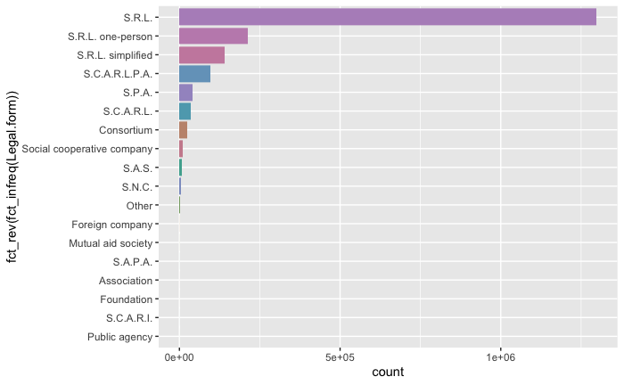

```r
ggplot(data=aida, aes(x=fct_rev(fct_infreq(Legal.form)), fill=Legal.form)) +
  geom_bar() +
  scale_fill_hue(c = 40) +
  theme(legend.position="none") +
  coord_flip()
```

#aida[,c(“ATECO.2007code”,“ATECO.Sector.Name”,“ATECO.Sector.Description”,“Failed”)]

Age

```r
# The company age is defined as as the difference between Incorporation.year and Last.accounting.closing.date
age.df <- aida

# Handle Incorporation.year: missing values occour
summary(age.df$Incorporation.year)
```

```
   Min. 1st Qu.  Median    Mean 3rd Qu.    Max.    NA's
   1900    1999    2006    2004    2012    2019     661
```

```r
# Handle Last.accounting.closing.date:  no missing values
summary(age.df$Last.accounting.closing.date)
```

```
   Min. 1st Qu.  Median    Mean 3rd Qu.    Max.
   1990    2012    2017    2015    2018    2019
```

```r
# Print the median for each sector of Incorporation.year
tapply(age.df$Incorporation.year,age.df$ATECO.Sector.Name,median, na.rm=TRUE)
```

```
        A         B         C         D         E         F         G         H         I         J         K         L         M         N no.sector         O
   2006.0    1995.0    2003.0    2010.0    2004.0    2006.0    2007.0    2007.0    2010.0    2007.0    2008.0    2004.0    2008.0    2008.0    2005.0    2004.5
        P         Q         R         S         T         U
   2008.0    2007.0    2009.0    2009.0    2012.0    2001.0
```

```r
# For each ATECO.Sector.Name group replace the 'Incorporation year' nan value with the respective median. In this way the result is more accurate than computing the median on entire Incorporation.year values.
compute.median <- function(x) replace(x, is.na(x), median(x, na.rm = TRUE))
age.df <- ddply(age.df,~ATECO.Sector.Name,transform, Incorporation.year = compute.median(`Incorporation.year`))

# Compute 'Age' attribute
age.df$Age <- age.df$Last.accounting.closing.date - age.df$Incorporation.year
age.df$Age <- as.integer(age.df$Age)
```

```r
# Anomalies

# There are some company with negative age, with Incorporation year greater then Last accounting closing date. We suppose that are digit error. Therefore we remove all that records
summary(age.df$Age)
```

```
   Min. 1st Qu.  Median    Mean 3rd Qu.    Max.
 -12.00    3.00    7.00   11.52   16.00  118.00
```

```r
head(age.df[age.df$Age > 35.5,c('Age','Last.accounting.closing.date','Incorporation.year')])
```

|  | Age | Last.accounting.closing.date | Incorporation.year |
| --- | --- | --- | --- |
| 5 | 52 | 2018 | 1966 |
| 44 | 41 | 2018 | 1977 |
| 59 | 40 | 2018 | 1978 |
| 80 | 41 | 2006 | 1965 |
| 98 | 70 | 2018 | 1948 |
| 103 | 53 | 2018 | 1965 |

```r
# Remove negative ages
age.df <- age.df[age.df$Age >= 0,]

# Age Anomaly Detection: iqr range approach
iqr <- IQR(age.df$Age)
q1 <- quantile(age.df$Age,0.25)
q3 <- quantile(age.df$Age,0.75)
lower.whisker <- q1 - 1.5*iqr
upper.whisker <- q3 + 1.5*iqr

outliers <- age.df[age.df$Age < lower.whisker | age.df$Age > upper.whisker,'Age']
table(outliers)
```

```
outliers
   36    37    38    39    40    41    42    43    44    45    46    47    48    49    50    51    52    53    54    55    56    57    58    59    60    61    62
 9155  9995 10453  7438  5930  5591  4928  4001  4165  4408  3507  2435  2269  2275  2075  1751  1558  1271  1239  1390  1434  1281  1057   891   721   792   686
   63    64    65    66    67    68    69    70    71    72    73    74    75    76    77    78    79    80    81    82    83    84    85    86    87    88    89
  710   679   745   723   676   656   664   515   504   492   407   155    96   110   213   166   173   142   145   126   132   135   128   130   122   127   132
   90    91    92    93    94    95    96    97    98    99   100   101   102   103   104   105   106   107   108   109   110   111   112   113   114   115   116
  133   121   148   205   104    94   105   115   162   127    41    23    26    35    35    49    48    71    43    56    63    53    48    40    32    25    38
  117   118
   26    22
```

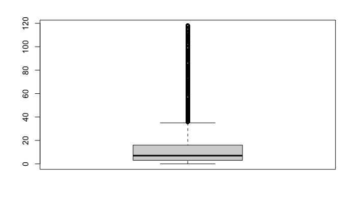

```r
boxplot(age.df$Age)
```

```r
# We decided to don't remove outliers because are not error/noise but companies with higher age. The boxplot shows that the age between the median and the maximum age is sparse.
```

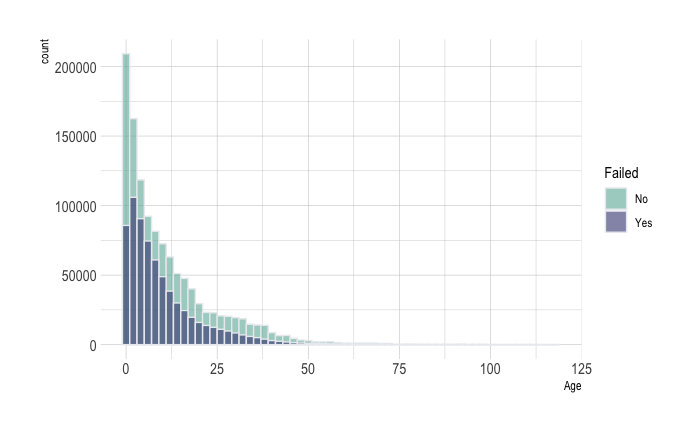

```r
ggplot(data = age.df) +
  geom_histogram(mapping=aes(x=Age, fill=Failed),binwidth = 2,color="#e9ecef", alpha=0.6, position = 'identity') +
    scale_fill_manual(values=c("#69b3a2", "#404080"))+
    theme_ipsum() +
    labs(fill='Failed')
```

Size

```r
# Il legislatore attribuisce la dimensione di un'azienda in base al totale degli elementi che costituiscono l'attivo dello stato patrimoniale, al risultato di esercizio ed al numero di dipendenti. Nel nostro caso abbiamo deciso di attribuire a size il totale delle attività dello sp, in particolare abbiamo considerato il totale degli assets nell'ultimo anno disponibile per esprimere il valore  degli impieghi di un'azienda.
size.df <- aida

# We consider all the company without nan value in total assets last available.
size.df <- size.df[!is.na(size.df$Total.assetsth.EURLast.avail..yr),]
summary(size.df$Total.assetsth.EURLast.avail..yr)
```

```
     Min.   1st Qu.    Median      Mean   3rd Qu.      Max.
0.000e+00 6.000e+01 2.380e+02 6.606e+03 8.880e+02 1.304e+09
```

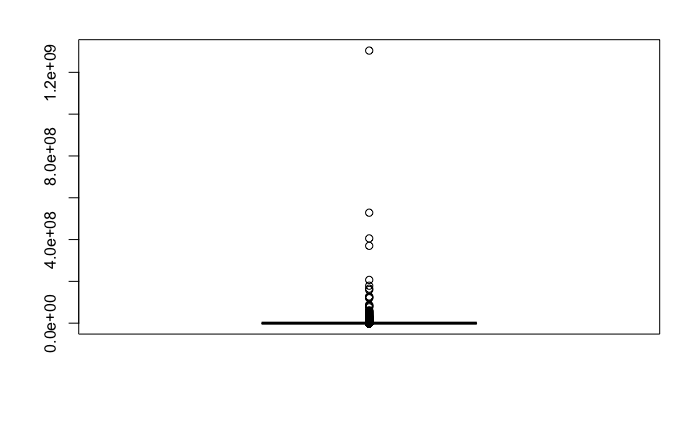

```r
# Anomaly detection

# Before outliers detection
boxplot(size.df$Total.assetsth.EURLast.avail..yr)
```

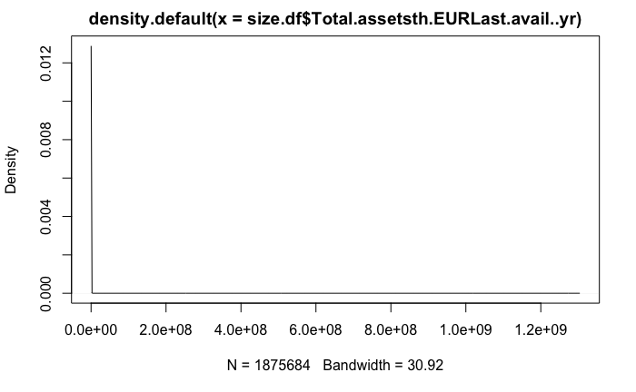

```r
plot(density(size.df$Total.assetsth.EURLast.avail..yr))
```

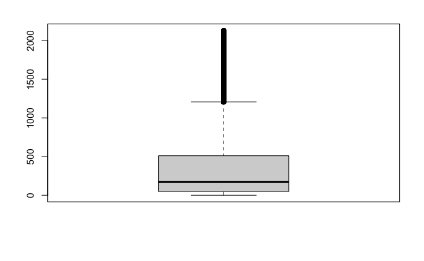

```r
# Size Anomaly Detection: iqr range approach
iqr <- IQR(size.df$Total.assetsth.EURLast.avail..yr)
q1 <- quantile(size.df$Total.assetsth.EURLast.avail..yr,0.25)
q3 <- quantile(size.df$Total.assetsth.EURLast.avail..yr,0.75)
lower.whisker <- q1 - 1.5*iqr
upper.whisker <- q3 + 1.5*iqr

# Remove all outliers not between [q1-1.5*iqr,q3+1.5*iqr] (external from two whiskers)
size.df <- size.df[size.df$Total.assetsth.EURLast.avail..yr >= lower.whisker & size.df$Total.assetsth.EURLast.avail..yr <= upper.whisker,]

#After outliers detection
boxplot(size.df$Total.assetsth.EURLast.avail..yr)
```

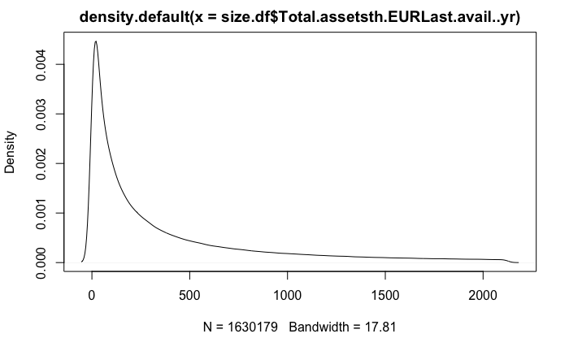

```r
plot(density(size.df$Total.assetsth.EURLast.avail..yr))
```

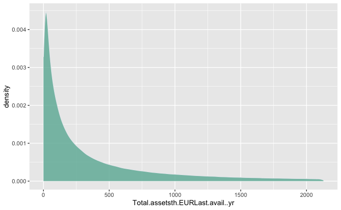

```r
# ggplot2 size plots

ggplot( data=size.df, aes(x=Total.assetsth.EURLast.avail..yr) ) +
    geom_density(fill="#69b3a2", color="#e9ecef", alpha=0.8)
```

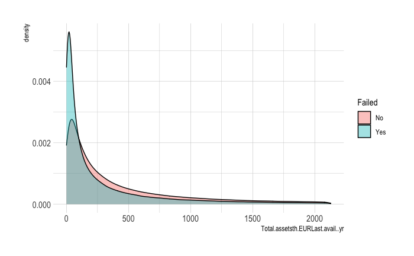

```r
ggplot(data=size.df, aes(x=Total.assetsth.EURLast.avail..yr, group=Failed, fill=Failed)) +
    geom_density(adjust=1.5, alpha=.4) +
    theme_ipsum()
```

ROI: Return on Investments

```r
# Reduce the aida dataset from all that companies which report ROI of all last three years. Obviously all missing values are been deleted. The dataset is composed by 386.629 companies (20.61%)
roi.df <- aida
colnames(roi.df)[65:67] <- c('ROI.last.avail','ROI.one.year.ago','ROI.two.years.ago')

b<- nrow(roi.df)
roi.df <- roi.df[!is.na(roi.df$ROI.last.avail),]
roi.df <- roi.df[!is.na(roi.df$ROI.one.year.ago),]
roi.df <- roi.df[!is.na(roi.df$ROI.two.years.ago),]
a <- nrow(roi.df)
ratio <- a*100/b

# Add attribute avg.roi which rappresents the average ROI of the last three years.
roi.df$avg.roi <- (roi.df$ROI.last.avail + roi.df$ROI.one.year.ago + roi.df$ROI.two.years.ago)/3

summary(roi.df$avg.roi)
```

```
    Min.  1st Qu.   Median     Mean  3rd Qu.     Max.
-29.6033  -0.6067   3.0467   3.8919   8.7467  29.6900
```

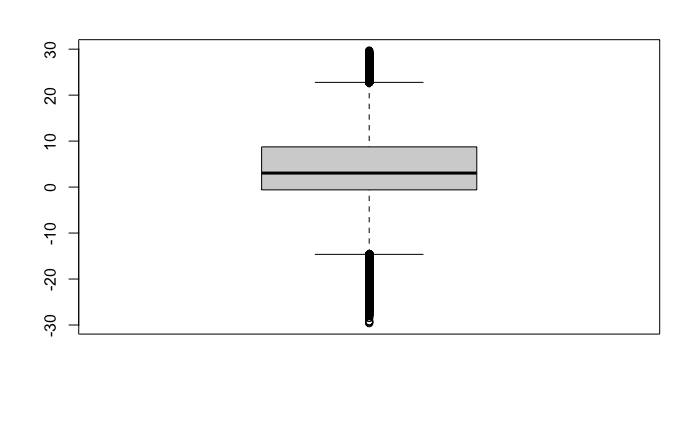

```r
# ROI Anomaly Detection: iqr range approach
iqr <- IQR(roi.df$avg.roi)
q1 <- quantile(roi.df$avg.roi,0.25)
q3 <- quantile(roi.df$avg.roi,0.75)
lower.whisker <- q1 - 1.5*iqr
upper.whisker <- q3 + 1.5*iqr

outliers <- roi.df[roi.df$avg.roi < lower.whisker | roi.df$avg.roi > upper.whisker,c('avg.roi')]
#table(outliers)
boxplot(roi.df$avg.roi)
```

```r
# The outliers are companies with the higher and lower roi. We don't remove these record because the roi dataset composed only from 20.61% of record and could be usefull.
```

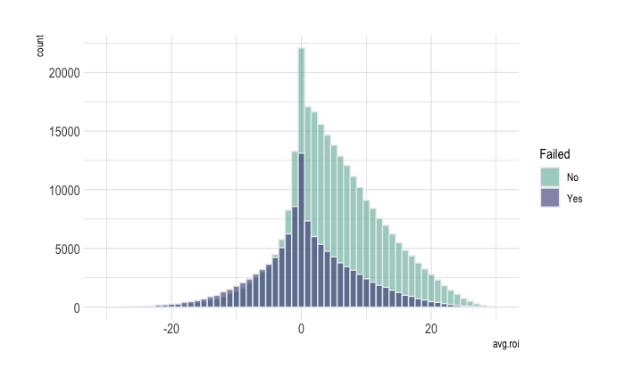

```r
ggplot(data = roi.df) +
  geom_histogram(mapping=aes(x=avg.roi, fill=Failed),binwidth = 1,color="#e9ecef", alpha=0.6, position = 'identity') +
    scale_fill_manual(values=c("#69b3a2", "#404080"))+
    theme_ipsum() +
    labs(fill='Failed')
```

Solvency Ratio

```r
summary(aida$`Solvency.ratio.(%)%Last.avail..yr`)
```

```
   Min. 1st Qu.  Median    Mean 3rd Qu.    Max.    NA's
 -50.00    5.57   21.30   29.90   52.23  100.00  193434
```

```r
# Deleting missing values
solvency.df <- aida

b<- nrow(solvency.df)
solvency.df <- solvency.df[!is.na(solvency.df$`Solvency.ratio.(%)%Last.avail..yr`),]
solvency.df <- solvency.df[!is.na(solvency.df$`Solvency.ratio.(%)%Year.-.1`),]
solvency.df <- solvency.df[!is.na(solvency.df$`Solvency.ratio.(%)%Year.-.2`),]
a <- nrow(solvency.df)
ratio <- a*100/b

# Add attribute avg.size which rappresents the average size of the last three years.
solvency.df$avg.solvency <- round((solvency.df$`Solvency.ratio.(%)%Last.avail..yr`
                              + solvency.df$`Solvency.ratio.(%)%Year.-.1` + solvency.df$`Solvency.ratio.(%)%Year.-.2`)/3)

summary(solvency.df$avg.solvency)
```

```
   Min. 1st Qu.  Median    Mean 3rd Qu.    Max.
 -50.00    7.00   22.00   29.96   49.00  100.00
```

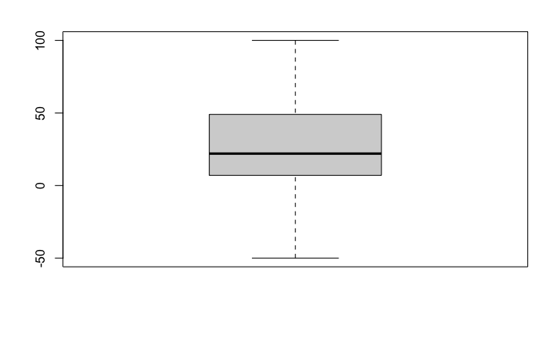

```r
# ROI Anomaly Detection: iqr range approach
iqr <- IQR(solvency.df$avg.solvency)
q1 <- quantile(solvency.df$avg.solvency,0.25)
q3 <- quantile(solvency.df$avg.solvency,0.75)
lower.whisker <- q1 - 1.5*iqr
upper.whisker <- q3 + 1.5*iqr

outliers <- solvency.df[solvency.df$avg.solvency < lower.whisker | solvency.df$avg.solvency > upper.whisker,c('avg.solvency')]
#table(outliers)
boxplot(solvency.df$avg.solvency)
```

```r
# The avg.solvency distribution is well balanced and doesn't show any anomaly
```

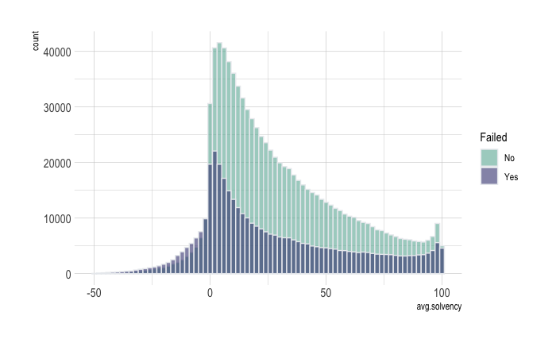

```r
ggplot(data = solvency.df) +
  geom_histogram(mapping=aes(x=avg.solvency, fill=Failed),binwidth = 2,color="#e9ecef", alpha=0.6, position = 'identity') +
    scale_fill_manual(values=c("#69b3a2", "#404080"))+
    theme_ipsum() +
    labs(fill='Failed')
```

QUESTION A Compare the distributions of size/age/other between failed and active companies at a specific year?

1.Abbiamo definito age, size°, roi° e solvency.ratio°. ° = media sui 3 anni precedenti - Quali e quante variabili dobbiamo confrontare nella domanda A? - Cosa intende per specific year? Devo filtrare un anno specifico quindi ridimensionare il dataset?

2. siamo in grado di rispondere alla domanda A nello stato in cui ci troviamo adesso?
- Posso utilizzare ad esempio un approccio non parametrico come la KDE appena vista a lezione per rispondere alle domande?
- fhat = kde.boundary(x=age,xmin=0, xmax=118,boundary.kernel=“beta”) su age non termina più…
- se uso density(age) mi restituisce cmq una boundary kde? il bandwitch sceglie quello ottimale?
3. Se metto la densità (freq = False) la somma delle densità torna sempre un valore diverso hist(age.df$Age,freq=FALSE,breaks=1) #la somma della densità ritorna 1 hist(age.df$Age,freq=FALSE,breaks=120) #la somma della densità ritorna 100 hist(age.df$Age,freq=FALSE,breaks=11,ylim=c(0.0,1.0)) #la somma della densità ritorna 0.1 hist(age.df$Age,freq=FALSE,breaks=“Sturges”) #la somma della densità ritorna ?
4. la anomaly dectection vista a lezione (IQR range) mi permette di trovare/eliminare gli outliers all’esterno degli intervalli <Q1-1.5*IQR e >Q3+1.5 IQR. E’ necessario determinare le anomalie per rispondere alle domande A e B o è più utile eliminarle solo quando facciamo la regressione (sensibile agli outliers)? Perchè dopo aver eliminato le anomalie all esterno dei whiskers se rieseguo il boxplot sulla nuova variabile si ripresentano ancora anomalie?
5. stesso discorso feature reduction. Non ha senso per le domande a e b, in tali casi eseguo il preprocess solo degli attributi che sto considerando. Ha senso farla solo nel caso della regressione nel nostro caso?
6. istogrammii e grafi preferisce con ggplot2 o con le funzioni (hist,barplot,lines…) viste a lezione? I grafici con ggplot2 sono belli ma non mi permettono ad esempio di avere il pieno controllo…esempio bandwitch, binsize ecc…